# Collecting Twitter Data About Blizzard

Joshua Timm

10/20/2019

## Setting up Our Credentials

The first thing to do is to set up a connection to the Twitter API. Follow these steps to create your token:

1. Go to apps.twitter.com and sign in.
2. Click on “Create New App”. You will need to have a phone number associated with your account in order to be able to create a token.
3. Fill name, description, and website (it can be anything, even http://www.google.com). Make sure you leave ‘Callback URL’ empty.
4. Agree to user conditions.
5. From the “Keys and Access Tokens” tab, copy consumer key and consumer secret and paste below
6. Note that it is *very* easy to forget where you log in to access your Twitter tokens in the future, so either try to remember https://apps.twitter.com or https://dev.twitter.com or just remember where this code file is!

```r
library(ROAuth)
requestURL <- "https://api.twitter.com/oauth/request_token"
accessURL <- "https://api.twitter.com/oauth/access_token"
authURL <- "https://api.twitter.com/oauth/authorize"
# using tweet_scraping_10, the name of the app on my personal twitter account at dev.twitter.com
consumerKey <- "asdf8a7sd8f7a6dfs8h76876876" # this is of course a fake number generated by mashing the keyboard
consumerSecret <- "adsf87as96gd98as7d698a7dg69a8s7d6g9876asdg9867" # this is also a fake token that will look somewhat like your real token
my_oauth <- OAuthFactory$new(consumerKey = consumerKey, consumerSecret = consumerSecret,
                             requestURL = requestURL, accessURL = accessURL, authURL = authURL)
```

Run the below line and go to the URL that appears on screen.

```r
my_oauth$handshake(cainfo = system.file("CurlSSL", "cacert.pem", package = "RCurl"))
```

When the handshake above works, your web browser should pop up with a twitter page asking you to authorize the app, which you do by clicking the big blue “Authorize App” button.

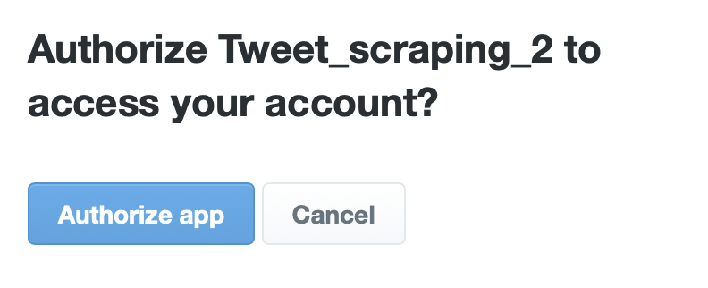

After clicking “Authorize App”, you should be given a code to copy and paste into your R console. The console should prompt you to type it in like so:

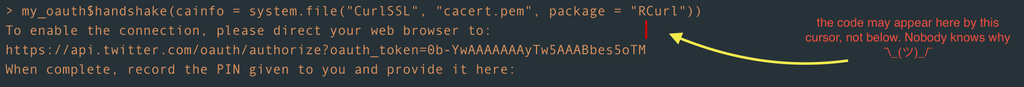

Then, type the PIN into the console (RStudio sometimes doesn’t show what you’re typing, but it’s there!). After that works properly and there are no errors, save the credentials to your system somewhere so you don’t have to authorize the token every time you want to collect Twitter data.

```r
save(my_oauth, file = "~/Dropbox/where/i/want/that/data/stored/twitter_oauth_1.Rdata")
```

## Collecting Tweets Using the Streaming API

To begin, let’s load our credentials that we just created, and use the *filterstream* function to collect a random sample of tweets containing the following terms: Blizzard, Activision-Blizzard, Activision Blizzard, Blizz, Hearthstone, and @Blizzard (to collect tweets directed at Blizzard). The *track* parameter within the *filterstream* function determines which terms to search for, and the *timeout* parameter determines how long the computer should actively access the streaming Twitter API and collect tweets, denoted in seconds To begin, let’s try 2 minutes, or 120 seconds. Right now the time is @ 3pm on October 20, 2019, so we’re bound to get some tweets about the whole uh… well, the news about Blizzard during a Hearthstone tournament.

```r
library(streamR)
load("~/icloud/credentials/twitter/twitter_oauth_10.Rdata")
filterStream("blizzard_tweets.json",
             track = c("Blizzard", "Activition-Blizzard", "Activision Blizzard", "Blizz", "Hearthstone", "@Blizzard"),
             timeout = 120,  oauth = my_oauth)
```